# Q1. Practice your skills.

```python
import os

import numpy as np
import matplotlib.pyplot as plt
import seaborn as sns
import rioxarray as rxr
import earthpy as et

# Prettier plotting with seaborn
sns.set(font_scale=1.5, style="whitegrid")
```

I first have to import different modules and packages to use the features mapping or otherwise to properly process the data.

```python
os.chdir(os.path.join(et.io.HOME,
                      'earth-analytics',
                      'data'))
```

This code here is used for setting the path so it can be able to access the files within the earth-analytics folder.

```python
# Define relative path to file
lidar_dem_path = os.path.join("colorado-flood",
                              "spatial",
                              "outputs",
                              "lidar_chm.tiff")

# Open lidar dem
lidar_dem_xr = rxr.open_rasterio(lidar_dem_path, masked=True).squeeze()
lidar_dem_xr
```

```
<xarray.DataArray (y: 2000, x: 4000)>
[8000000 values with dtype=float32]
Coordinates:
    band         int64 1
  * x            (x) float64 4.72e+05 4.72e+05 4.72e+05 ... 4.76e+05 4.76e+05
  * y            (y) float64 4.436e+06 4.436e+06 ... 4.434e+06 4.434e+06
    spatial_ref  int64 0
Attributes:
    scale_factor:  1.0
    add_offset:    0.0
```

From here, I created the variable 'lidar_dem_path' to access the 'lidar_chm.tiff' by creating the relative path to that file. Then I made another variable 'lidar_dem_xr' to open the lidar dem using rioxarray to be used for mapping later.

```python
# Make sure that your output data has a crs & no data value defined
print("The crs is", lidar_dem_xr.rio.crs)
print("The no data value is", lidar_dem_xr.rio.nodata)
```

```
The crs is EPSG:32613
The no data value is nan
```

This code shows whether if 'lidar_dem_xr' has a crs value already defined to be able to be mapped. The no data value makes me see if there is no data that could potentially conflict with producing the map. The crs seems to be correct, however, the no data value is not correct. Instead of saying 'None' for the no data value, it says 'nan' which most likely means it's not properly defined.

```python
# Define relative path to file
lidar_dsm_path = os.path.join("colorado-flood",
                              "spatial",
                              "outputs",
                              "lidar_chm.tiff")

# Open lidar dem
lidar_dsm_xr = rxr.open_rasterio(lidar_dsm_path, masked=True).squeeze()
lidar_dsm_xr
```

```
<xarray.DataArray (y: 2000, x: 4000)>
[8000000 values with dtype=float32]
Coordinates:
    band         int64 1
  * x            (x) float64 4.72e+05 4.72e+05 4.72e+05 ... 4.76e+05 4.76e+05
  * y            (y) float64 4.436e+06 4.436e+06 ... 4.434e+06 4.434e+06
    spatial_ref  int64 0
Attributes:
    scale_factor:  1.0
    add_offset:    0.0
```

I also created the variable 'lidar_dsm_path' to access the 'lidar_chm.tiff' by creating the relative path to that file. Then I made another variable 'lidar_dsm_xr' to open the lidar dem using rioxarray to be used for mapping later.

```python
# Make sure that your output data has a crs & no data value defined
print("The crs is", lidar_dsm_xr.rio.crs)
print("The no data value is", lidar_dsm_xr.rio.nodata)
```

```
The crs is EPSG:32613
The no data value is nan
```

This code shows whether if 'lidar_dsm_xr' has a crs value already defined to be able to be mapped. The no data value makes me see if there is no data that could potentially conflict with producing the map. The crs seems to be correct, however, the no data value is not correct. Instead of saying 'None' for the no data value, it says 'nan' which most likely means it's not properly defined.

```python
# Are the bounds the same?
print("Is the spatial extent the same?",
      lidar_dem_xr.rio.bounds() == lidar_dsm_xr.rio.bounds())

# Is the resolution the same ??
print("Is the resolution the same?",
      lidar_dem_xr.rio.resolution() == lidar_dsm_xr.rio.resolution())
```

```
Is the spatial extent the same? True
Is the resolution the same? True
```

After creating the dem and dsm varaibles, I then compare them to each other to see if the values are the same for the spatial extent and for the resolution. this is to make sure that there are no differences when I create the map.

[figure not shown]

```python
# Calculate canopy height model
lidar_chm_xr = lidar_dsm_xr - lidar_dem_xr

# Plot the data
f, ax = plt.subplots(figsize=(10, 5))
lidar_chm_xr.plot(cmap="Greens")
ax.set(title="Canopy Height Model for Lee Hill Road Pre-Flood")
ax.set_axis_off()
plt.show()
```

# Q2. Plot Change Over Time

## 1st Map

```python
import os

import matplotlib.pyplot as plt
from matplotlib.colors import ListedColormap, BoundaryNorm
import numpy as np
import xarray as xr
import rioxarray as rxr
import earthpy as et
import earthpy.plot as ep

# Prettier plotting with seaborn
import seaborn as sns
sns.set(font_scale=1.5, style="whitegrid")
```

I first have to import different modules and packages to use the features mapping or otherwise to properly process the data.

```python
## set working directory

os.chdir(os.path.join(et.io.HOME,
                      'earth-analytics',
                      'data'))
```

This code here is used for setting the path so it can be able to access the files within the earth-analytics folder to get to the pre and post files in the 'boulder-leehill-rd' folder.

```python
# Define relative paths to DTM and DSM files
dtm_path = os.path.join("colorado-flood",
                        "spatial",
                        "boulder-leehill-rd",
                        "pre-flood",
                        "lidar",
                        "pre_DTM.tif")

dsm_path = os.path.join("colorado-flood",
                        "spatial",
                        "boulder-leehill-rd",
                        "pre-flood",
                        "lidar",
                        "pre_DSM.tif")

# Open DTM and DSM files
pre_lidar_dtm = rxr.open_rasterio(dtm_path, masked=True).squeeze()
pre_lidar_dsm = rxr.open_rasterio(dsm_path, masked=True).squeeze()

# Create canopy height model (CHM)
pre_lidar_chm = pre_lidar_dsm - pre_lidar_dtm
pre_lidar_chm
```

```
<xarray.DataArray (y: 2000, x: 4000)>
array([[       nan,        nan,        nan, ..., 0.        , 0.17004395,
        0.960083  ],
       [       nan,        nan,        nan, ..., 0.        , 0.09008789,
        1.6400146 ],
       [       nan,        nan,        nan, ..., 0.        , 0.        ,
        0.07995605],
       ...,
       [       nan,        nan,        nan, ..., 0.        , 0.        ,
        0.        ],
       [       nan,        nan,        nan, ..., 0.        , 0.        ,
        0.        ],
       [       nan,        nan,        nan, ..., 0.        , 0.        ,
        0.        ]], dtype=float32)
Coordinates:
    band         int64 1
  * x            (x) float64 4.72e+05 4.72e+05 4.72e+05 ... 4.76e+05 4.76e+05
  * y            (y) float64 4.436e+06 4.436e+06 ... 4.434e+06 4.434e+06
    spatial_ref  int64 0
```

From here, I created the variable 'dtm_path' to access the 'pre_DTM.tif' by creating the relative path to that file. Then I made another variable 'dsm_path' to have a relative path to the 'pre_DSM.tif' file. After that I opened the files creating the 'pre_lidar_dtm' and 'pre_lidar_dsm' variables and using the rioxarray to be used for mapping later. Lastly, I subtracted both the dsm and dtm together to create the canopy height model since both the files are safe to subtract and won't cause major problems down the line.

```python
# Define relative paths to DTM and DSM files
pst_dtm_path = os.path.join("colorado-flood",
                        "spatial",
                        "boulder-leehill-rd",
                        "post-flood",
                        "lidar",
                        "post_DTM.tif")

pst_dsm_path = os.path.join("colorado-flood",
                        "spatial",
                        "boulder-leehill-rd",
                        "post-flood",
                        "lidar",
                        "post_DSM.tif")

# Open DTM and DSM files
post_lidar_dtm = rxr.open_rasterio(pst_dtm_path, masked=True).squeeze()
post_lidar_dsm = rxr.open_rasterio(pst_dsm_path, masked=True).squeeze()

# Create canopy height model (CHM)
post_lidar_chm = post_lidar_dsm - post_lidar_dtm
post_lidar_chm
```

```
<xarray.DataArray (y: 2000, x: 4000)>
array([[0.02001953, 0.        , 0.        , ..., 0.        , 0.        ,
        0.98010254],
       [0.        , 0.        , 0.        , ..., 0.        , 0.        ,
        1.4000244 ],
       [0.        , 0.        , 0.        , ..., 0.        , 0.        ,
        0.        ],
       ...,
       [0.        , 0.        , 0.        , ..., 0.        , 0.        ,
        0.        ],
       [0.        , 0.        , 0.        , ..., 0.        , 0.        ,
        0.        ],
       [0.04003906, 0.        , 0.        , ..., 0.        , 0.        ,
        0.        ]], dtype=float32)
Coordinates:
    band         int64 1
  * x            (x) float64 4.72e+05 4.72e+05 4.72e+05 ... 4.76e+05 4.76e+05
  * y            (y) float64 4.436e+06 4.436e+06 ... 4.434e+06 4.434e+06
    spatial_ref  int64 0
```

To also make the post-flood files, I used the exact same steps when i made the pre-flood files. I created the variable 'pst_dtm_path' to access the 'post_DTM.tif' by creating the relative path to that file. Then I made another variable 'pst_dsm_path' to have a relative path to the 'post_DSM.tif' file. After that I opened the files creating the 'post_lidar_dtm' and 'post_lidar_dsm' variables and using the rioxarray to be used for mapping later. Lastly, I subtracted both the dsm and dtm together to create the canopy height model since both the files are safe to subtract and won't cause major problems down the line.

```python
# Create canopy model (CHM) for both pre and post files
pre_post_lidar_chm = pre_lidar_chm - post_lidar_chm
pre_post_lidar_chm
```

```
<xarray.DataArray (y: 2000, x: 4000)>
array([[        nan,         nan,         nan, ...,  0.        ,
         0.17004395, -0.02001953],
       [        nan,         nan,         nan, ...,  0.        ,
         0.09008789,  0.23999023],
       [        nan,         nan,         nan, ...,  0.        ,
         0.        ,  0.07995605],
       ...,
       [        nan,         nan,         nan, ...,  0.        ,
         0.        ,  0.        ],
       [        nan,         nan,         nan, ...,  0.        ,
         0.        ,  0.        ],
       [        nan,         nan,         nan, ...,  0.        ,
         0.        ,  0.        ]], dtype=float32)
Coordinates:
    band         int64 1
  * x            (x) float64 4.72e+05 4.72e+05 4.72e+05 ... 4.76e+05 4.76e+05
  * y            (y) float64 4.436e+06 4.436e+06 ... 4.434e+06 4.434e+06
    spatial_ref  int64 0
```

After creating the canopy models, I then took the canopy amounts from both pre and post chm files and subtracted them to each other. The variable 'pre_post_lidar_chm' was made to hold the canopy height of 'pre_lidar_chm' and 'post_lidar_chm'.

```python
##Set our bins
class_bins = [-np.inf, 2, 7, 12, np.inf]
class_bins
```

```
[-inf, 2, 7, 12, inf]
```

This code creates the class bins assigning values.

```python
##Here we're using the xarray library to apply numpy's digitize function
##this code creates a new object (pre_lidar_chm_class) by applying digitize to our former object (pre_lidar_chm)
##using the class_bins we designated above

pre_post_lidar_chm_class = xr.apply_ufunc(np.digitize,
                                     pre_post_lidar_chm,
                                     class_bins)
```

This code shows that xarray will utilize numpy's digitize function. It creates a new object 'pre_post_lidar_chm_class' by applying the former object 'pre_post_lidar_chm' using the class bins from earlier.

```python
# Mask out values not equalt to 5
pre_post_lidar_chm_class_ma = pre_post_lidar_chm_class.where(pre_post_lidar_chm_class != 5)
pre_post_lidar_chm_class_ma
```

```
<xarray.DataArray (y: 2000, x: 4000)>
array([[nan, nan, nan, ...,  1.,  1.,  1.],
       [nan, nan, nan, ...,  1.,  1.,  1.],
       [nan, nan, nan, ...,  1.,  1.,  1.],
       ...,
       [nan, nan, nan, ...,  1.,  1.,  1.],
       [nan, nan, nan, ...,  1.,  1.,  1.],
       [nan, nan, nan, ...,  1.,  1.,  1.]])
Coordinates:
    band         int64 1
  * x            (x) float64 4.72e+05 4.72e+05 4.72e+05 ... 4.76e+05 4.76e+05
  * y            (y) float64 4.436e+06 4.436e+06 ... 4.434e+06 4.434e+06
    spatial_ref  int64 0
```

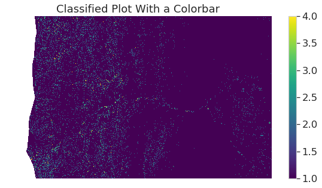

```python
# Plot newly classified and masked raster
f, ax = plt.subplots(figsize=(10,5))
pre_post_lidar_chm_class_ma.plot.imshow()
ax.set(title="Classified Plot With a Colorbar")

ax.set_axis_off()
plt.show()
```

This code shows a plot of the data that excludes the data that didn't show. It clearly shows the data and layers of the trees showing the data of the pre and post floods.

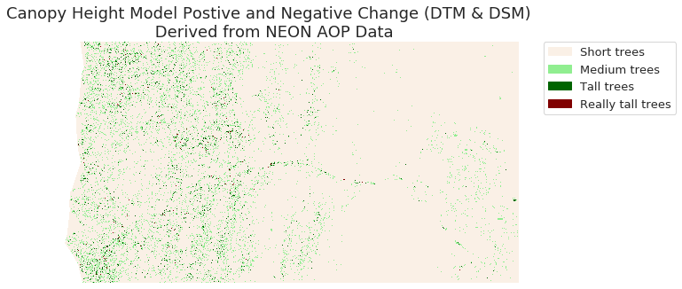

```python
# Create a list of labels to use for your legend
height_class_labels = ["Short trees",
                       "Medium trees",
                       "Tall trees",
                       "Really tall trees"]

# Create a colormap from a list of colors
colors = ['linen',
          'lightgreen',
          'darkgreen',
          'maroon']

cmap = ListedColormap(colors)

class_bins = [.5, 1.5, 2.5, 3.5, 4.5]
norm = BoundaryNorm(class_bins,
                    len(colors))

# Plot newly classified and masked raster
f, ax = plt.subplots(figsize=(10, 5))
im = pre_post_lidar_chm_class_ma.plot.imshow(cmap=cmap,
                                        norm=norm,
                                        # Turn off colorbar
                                        add_colorbar=False)
# Add legend using earthpy
ep.draw_legend(im,
               titles=height_class_labels)
ax.set(title="Canopy Height Model Postive and Negative Change (DTM & DSM) \n Derived from NEON AOP Data")
ax.set_axis_off()
plt.show()
```

## 2nd Map

```python
# Define relative paths to DTM and DSM files
pre_dtm_path = os.path.join("colorado-flood",
                        "spatial",
                        "boulder-leehill-rd",
                        "pre-flood",
                        "lidar",
                        "pre_DTM.tif")

pst_dtm_path = os.path.join("colorado-flood",
                        "spatial",
                        "boulder-leehill-rd",
                        "post-flood",
                        "lidar",
                        "post_DTM.tif")

# Open DTM and DSM files
pre_lidar_dtm = rxr.open_rasterio(pre_dtm_path, masked=True).squeeze()
post_lidar_dtm = rxr.open_rasterio(pst_dtm_path, masked=True).squeeze()

# Create canopy height model (CHM)
pre_post_dtm_lidar_chm = pre_lidar_dtm - post_lidar_dtm
pre_post_dtm_lidar_chm
```

```
<xarray.DataArray (y: 2000, x: 4000)>
array([[        nan,         nan,         nan, ...,  0.05004883,
        -0.10998535, -0.09997559],
       [        nan,         nan,         nan, ..., -0.05993652,
         0.01989746, -0.20996094],
       [        nan,         nan,         nan, ..., -0.14001465,
         0.01000977, -0.11999512],
       ...,
       [        nan,         nan,         nan, ..., -1.420044  ,
        -1.4199219 , -1.5599365 ],
       [        nan,         nan,         nan, ..., -0.67993164,
        -0.97998047, -1.0700684 ],
       [        nan,         nan,         nan, ..., -0.29992676,
        -0.4699707 , -0.60998535]], dtype=float32)
Coordinates:
    band         int64 1
  * x            (x) float64 4.72e+05 4.72e+05 4.72e+05 ... 4.76e+05 4.76e+05
  * y            (y) float64 4.436e+06 4.436e+06 ... 4.434e+06 4.434e+06
    spatial_ref  int64 0
```

```python
##Set our bins
class_bins = [-np.inf, 2, 7, 12, np.inf]
class_bins
```

```
[-inf, 2, 7, 12, inf]
```

This code creates the class bins assigning values.

```python
##Here we're using the xarray library to apply numpy's digitize function
##this code creates a new object (pre_lidar_chm_class) by applying digitize to our former object (pre_lidar_chm)
##using the class_bins we designated above

pre_post_dtm_lidar_chm_class = xr.apply_ufunc(np.digitize,
                                     pre_post_dtm_lidar_chm,
                                     class_bins)
```

This code shows that xarray will utilize numpy's digitize function. It creates a new object 'pre_post_dtm_lidar_chm_class' by applying the former object 'pre_post_dtm_lidar_chm' using the class bins from earlier.

```python
# Mask out values not equalt to 5
pre_post_dtm_lidar_chm_class_ma = pre_post_dtm_lidar_chm_class.where(pre_post_dtm_lidar_chm_class != 5)
pre_post_dtm_lidar_chm_class_ma
```

```
<xarray.DataArray (y: 2000, x: 4000)>
array([[nan, nan, nan, ...,  1.,  1.,  1.],
       [nan, nan, nan, ...,  1.,  1.,  1.],
       [nan, nan, nan, ...,  1.,  1.,  1.],
       ...,
       [nan, nan, nan, ...,  1.,  1.,  1.],
       [nan, nan, nan, ...,  1.,  1.,  1.],
       [nan, nan, nan, ...,  1.,  1.,  1.]])
Coordinates:
    band         int64 1
  * x            (x) float64 4.72e+05 4.72e+05 4.72e+05 ... 4.76e+05 4.76e+05
  * y            (y) float64 4.436e+06 4.436e+06 ... 4.434e+06 4.434e+06
    spatial_ref  int64 0
```

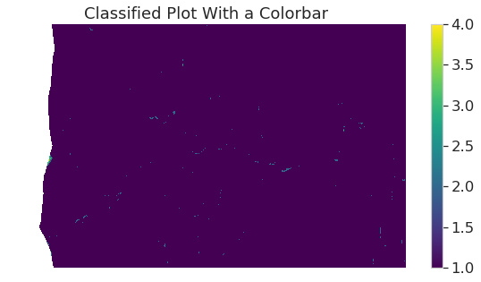

```python
# Plot newly classified and masked raster
f, ax = plt.subplots(figsize=(10,5))
pre_post_dtm_lidar_chm_class_ma.plot.imshow()
ax.set(title="Classified Plot With a Colorbar")

ax.set_axis_off()
plt.show()
```

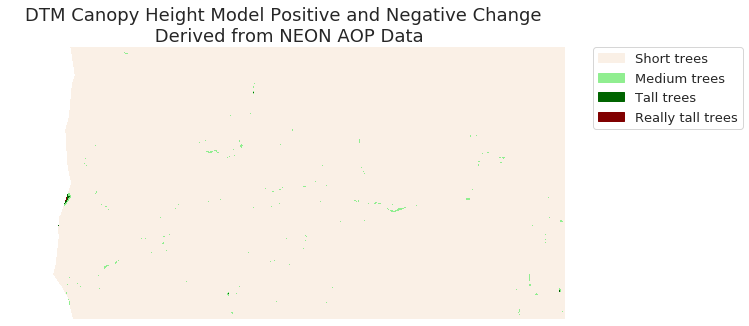

```python
# Create a list of labels to use for your legend
height_class_labels = ["Short trees",
                       "Medium trees",
                       "Tall trees",
                       "Really tall trees"]

# Create a colormap from a list of colors
colors = ['linen',
          'lightgreen',
          'darkgreen',
          'maroon']

cmap = ListedColormap(colors)

class_bins = [.5, 1.5, 2.5, 3.5, 4.5]
norm = BoundaryNorm(class_bins,
                    len(colors))

# Plot newly classified and masked raster
f, ax = plt.subplots(figsize=(10, 5))
im = pre_post_dtm_lidar_chm_class_ma.plot.imshow(cmap=cmap,
                                        norm=norm,
                                        # Turn off colorbar
                                        add_colorbar=False)
# Add legend using earthpy
ep.draw_legend(im,
               titles=height_class_labels)
ax.set(title="DTM Canopy Height Model Positive and Negative Change \n Derived from NEON AOP Data")
ax.set_axis_off()
plt.show()
```